# Analyse des Correspondances Multiples

Cheikh Talla

Mars 2023

# Analyse des Correspondances Multiples (ACM)

L’Analyse des Correspondances Multiples (ACM ou MCA pour multiple correspondence analysis) permet de résumer et visualiser un tableau de données contenant plus de deux variables catégorielles. On peut aussi la considérer comme une généralisation de l’analyse en composantes principales lorsque les variables à analyser sont catégorielles plutôt que quantitatives (Abdi and Williams 2010).

L’ACM est généralement utilisée pour analyser des données d’enquête ou de sondage.Le but est de trouver les groupes de personnes ayant un profil similaire dans leurs réponses aux questions.

```r
library("FactoMineR")
library("factoextra")
library(corrplot)
# jeu de données disponible dans le package FactoMineR
data(poison)
 head(poison)
```

```
  Age Time   Sick Sex   Nausea Vomiting Abdominals   Fever   Diarrhae   Potato
1   9   22 Sick_y   F Nausea_y  Vomit_n     Abdo_y Fever_y Diarrhea_y Potato_y
2   5    0 Sick_n   F Nausea_n  Vomit_n     Abdo_n Fever_n Diarrhea_n Potato_y
3   6   16 Sick_y   F Nausea_n  Vomit_y     Abdo_y Fever_y Diarrhea_y Potato_y
4   9    0 Sick_n   F Nausea_n  Vomit_n     Abdo_n Fever_n Diarrhea_n Potato_y
5   7   14 Sick_y   M Nausea_n  Vomit_y     Abdo_y Fever_y Diarrhea_y Potato_y
6  72    9 Sick_y   M Nausea_n  Vomit_n     Abdo_y Fever_y Diarrhea_y Potato_y
    Fish   Mayo Courgette   Cheese   Icecream
1 Fish_y Mayo_y   Courg_y Cheese_y Icecream_y
2 Fish_y Mayo_y   Courg_y Cheese_n Icecream_y
3 Fish_y Mayo_y   Courg_y Cheese_y Icecream_y
4 Fish_y Mayo_n   Courg_y Cheese_y Icecream_y
5 Fish_y Mayo_y   Courg_y Cheese_y Icecream_y
6 Fish_n Mayo_y   Courg_y Cheese_y Icecream_y
```

Ces données proviennent d’une enquête menée auprès d’enfants de l’école primaire qui ont subi des intoxications alimentaires. Ils ont été interrogés sur leurs symptômes et sur ce qu’ils ont mangé.

Les données contiennent 55 lignes (individus) et 15 colonnes (variables). Extraction les individus actifs et les variables actives pour l’ACM

```r
poison.active <- poison[, 5:15]
# Résumé des 4 premières variables
summary(poison.active)
```

```
      Nausea      Vomiting   Abdominals     Fever          Diarrhae
 Nausea_n:43   Vomit_n:33   Abdo_n:18   Fever_n:20   Diarrhea_n:20
 Nausea_y:12   Vomit_y:22   Abdo_y:37   Fever_y:35   Diarrhea_y:35
      Potato       Fish        Mayo      Courgette       Cheese
 Potato_n: 3   Fish_n: 1   Mayo_n:10   Courg_n: 5   Cheese_n: 7
 Potato_y:52   Fish_y:54   Mayo_y:45   Courg_y:50   Cheese_y:48
       Icecream
 Icecream_n: 4
 Icecream_y:51
```

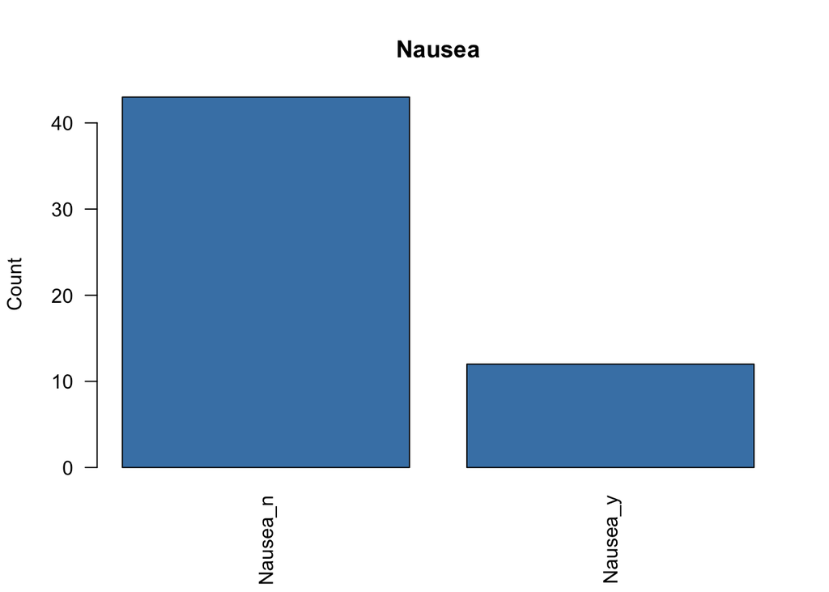

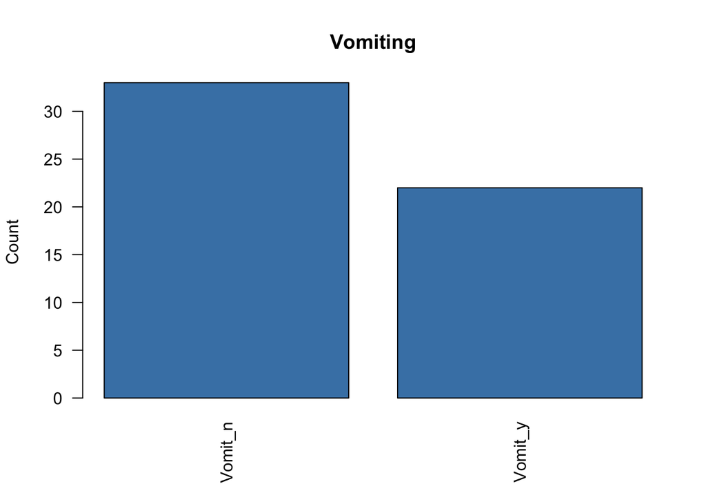

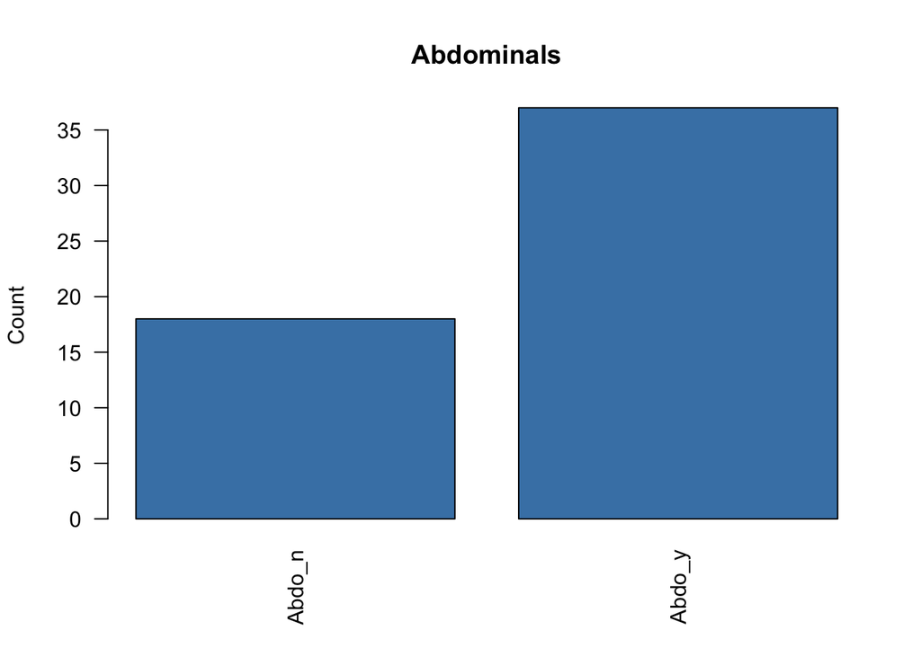

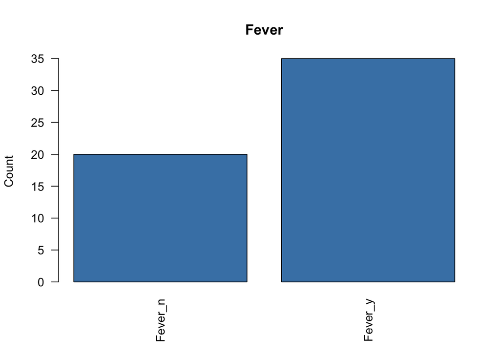

```r
for (i in 1:4) {
  plot(poison.active[,i], main = colnames(poison.active)[i],
       ylab = "Count", col="steelblue", las = 2)
  }
```

## MCA

Elle est faite sur les individus et variables actifs

```r
res.mca <- MCA (poison.active, graph = FALSE)
res.mca
```

```
**Results of the Multiple Correspondence Analysis (MCA)**
The analysis was performed on 55 individuals, described by 11 variables
*The results are available in the following objects:

   name              description
1  "$eig"            "eigenvalues"
2  "$var"            "results for the variables"
3  "$var$coord"      "coord. of the categories"
4  "$var$cos2"       "cos2 for the categories"
5  "$var$contrib"    "contributions of the categories"
6  "$var$v.test"     "v-test for the categories"
7  "$ind"            "results for the individuals"
8  "$ind$coord"      "coord. for the individuals"
9  "$ind$cos2"       "cos2 for the individuals"
10 "$ind$contrib"    "contributions of the individuals"
11 "$call"           "intermediate results"
12 "$call$marge.col" "weights of columns"
13 "$call$marge.li"  "weights of rows"
```

### Visualisation et interprétation

1. **get_eigenvalue(res.mca)**: Extraction des valeurs propres / variances des composantes principales
2. **fviz_eig(res.mca)**: Visualisation des valeurs propres
3. **get_mca_ind(res.mca), get_mca_var(res.mca)**: Extraction des résultats pour les individus et les variables, respectivement.
4. **fviz_mca_ind(res.mca), fviz_mca_var(res.mca)**: visualisation des résultats des individus et des variables, respectivement.
5. **fviz_mca_biplot(res.mca)**: Création d’un biplot des individus et des variables.

### Valeurs propres / Variances

```r
# pour avoir le tableau des valeurs propres
eig.val <- get_eigenvalue(res.mca)
eig.val
```

```
       eigenvalue variance.percent cumulative.variance.percent
Dim.1  0.33523140        33.523140                    33.52314
Dim.2  0.12913979        12.913979                    46.43712
Dim.3  0.10734849        10.734849                    57.17197
Dim.4  0.09587950         9.587950                    66.75992
Dim.5  0.07883277         7.883277                    74.64319
Dim.6  0.07108981         7.108981                    81.75217
Dim.7  0.06016580         6.016580                    87.76876
Dim.8  0.05577301         5.577301                    93.34606
Dim.9  0.04120578         4.120578                    97.46663
Dim.10 0.01304158         1.304158                    98.77079
Dim.11 0.01229208         1.229208                   100.00000
```

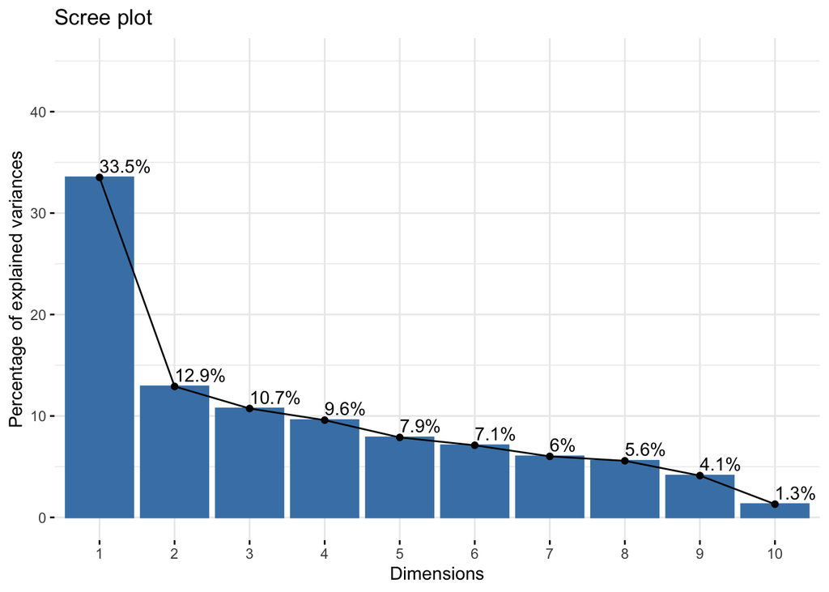

```r
 # pour visualiser le pourcentage de variance expliquée
fviz_screeplot (res.mca, addlabels = TRUE, ylim = c (0, 45))
```

### Visualiser le biplot des individus et des variables

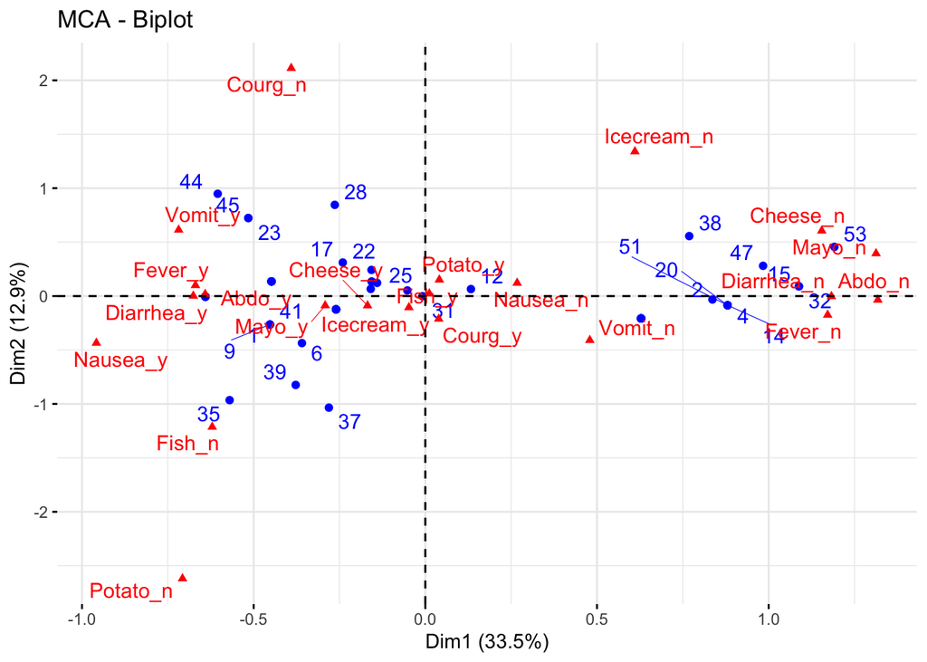

```r
fviz_mca_biplot (res.mca, repel = TRUE,
               ggtheme = theme_minimal())
```

### Graphique des variables

```r
var <- get_mca_var(res.mca)
var
```

```
Multiple Correspondence Analysis Results for variables
 ===================================================
  Name       Description
1 "$coord"   "Coordinates for categories"
2 "$cos2"    "Cos2 for categories"
3 "$contrib" "contributions of categories"
```

1. **var$coord**: coordonnées des variables pour créer un nuage de points
2. **var$cos2**: qualité de représentation des variables.
3. **var$contrib**: contributions (en pourcentage) des variables à la définition des dimensions.

```r
# Coordonnées
head(var$coord)
```

```
              Dim 1       Dim 2        Dim 3       Dim 4       Dim 5
Nausea_n  0.2673909  0.12139029 -0.265583253  0.03376130  0.07370500
Nausea_y -0.9581506 -0.43498187  0.951673323 -0.12097801 -0.26410958
Vomit_n   0.4790279 -0.40919465  0.084492799  0.27361142  0.05245250
Vomit_y  -0.7185419  0.61379197 -0.126739198 -0.41041713 -0.07867876
Abdo_n    1.3180221 -0.03574501 -0.005094243 -0.15360951 -0.06986987
Abdo_y   -0.6411999  0.01738946  0.002478280  0.07472895  0.03399075
```

```r
# Cos2: qualité de représentation
head(var$cos2)
```

```
             Dim 1        Dim 2        Dim 3       Dim 4       Dim 5
Nausea_n 0.2562007 0.0528025759 2.527485e-01 0.004084375 0.019466197
Nausea_y 0.2562007 0.0528025759 2.527485e-01 0.004084375 0.019466197
Vomit_n  0.3442016 0.2511603912 1.070855e-02 0.112294813 0.004126898
Vomit_y  0.3442016 0.2511603912 1.070855e-02 0.112294813 0.004126898
Abdo_n   0.8451157 0.0006215864 1.262496e-05 0.011479077 0.002374929
Abdo_y   0.8451157 0.0006215864 1.262496e-05 0.011479077 0.002374929
```

```r
# Contributions aux axes
head(var$contrib)
```

```
             Dim 1       Dim 2        Dim 3      Dim 4      Dim 5
Nausea_n  1.515869  0.81100008 4.670018e+00 0.08449397 0.48977906
Nausea_y  5.431862  2.90608363 1.673423e+01 0.30277007 1.75504164
Vomit_n   3.733667  7.07226253 3.627455e-01 4.25893721 0.19036376
Vomit_y   5.600500 10.60839380 5.441183e-01 6.38840581 0.28554563
Abdo_n   15.417637  0.02943661 7.192511e-04 0.73219636 0.18424268
Abdo_y    7.500472  0.01432051 3.499060e-04 0.35620363 0.08963157
```

### Corrélation entre les variables et les axes principaux

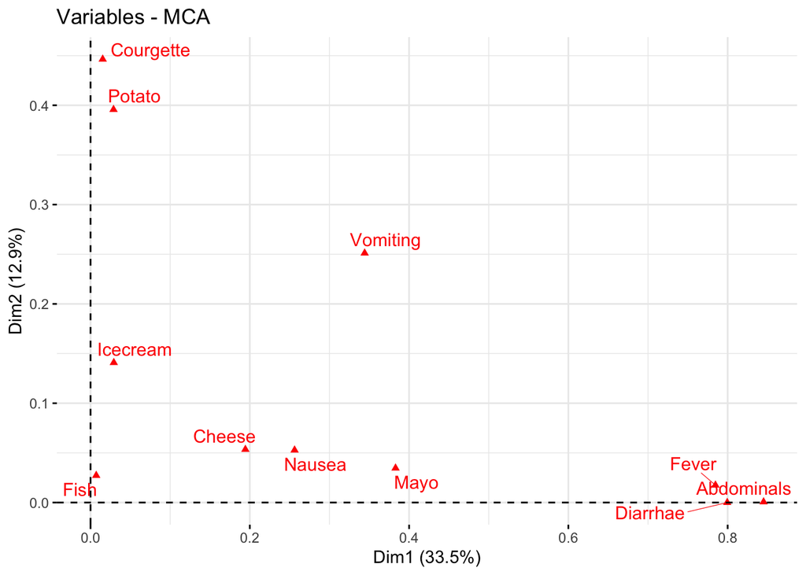

```r
fviz_mca_var (res.mca, choice = "mca.cor",
            repel = TRUE,
            ggtheme = theme_minimal ())
```

Le graphique ci-dessus permet d’identifier les variables les plus corrélées avec chaque axe. Les corrélations au carré entre les variables et les axes sont utilisées comme coordonnées.

Les variables Diarrhae, Abdominals et Fever sont les plus corrélées avec la première dimension. Les variables Courgette et Potato sont les plus corrélées avec la deuxième dimension.

### Coordonnées des catégories des variables

```r
head(round(var$coord, 2), 4)
```

```
         Dim 1 Dim 2 Dim 3 Dim 4 Dim 5
Nausea_n  0.27  0.12 -0.27  0.03  0.07
Nausea_y -0.96 -0.43  0.95 -0.12 -0.26
Vomit_n   0.48 -0.41  0.08  0.27  0.05
Vomit_y  -0.72  0.61 -0.13 -0.41 -0.08
```

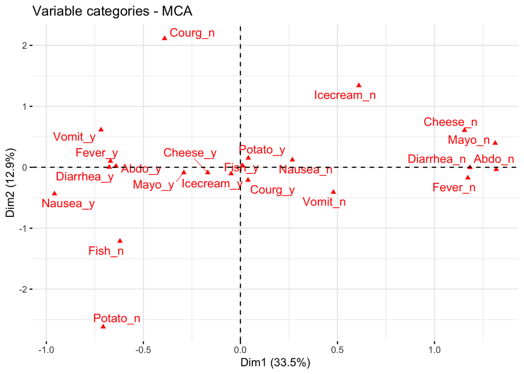

```r
fviz_mca_var (res.mca,
             repel = TRUE,
             ggtheme = theme_minimal ())
```

Les catégories avec un profil similaire sont regroupées. Les catégories corrélées négativement sont positionnées sur les côtés opposés de l’origine du graphique (quadrants opposés). La distance entre les catégories et l’origine mesure la qualité des catégories. Les points qui sont loin de l’origine sont bien représentés par l’ACM.

### Qualité de représentation des catégories des variables

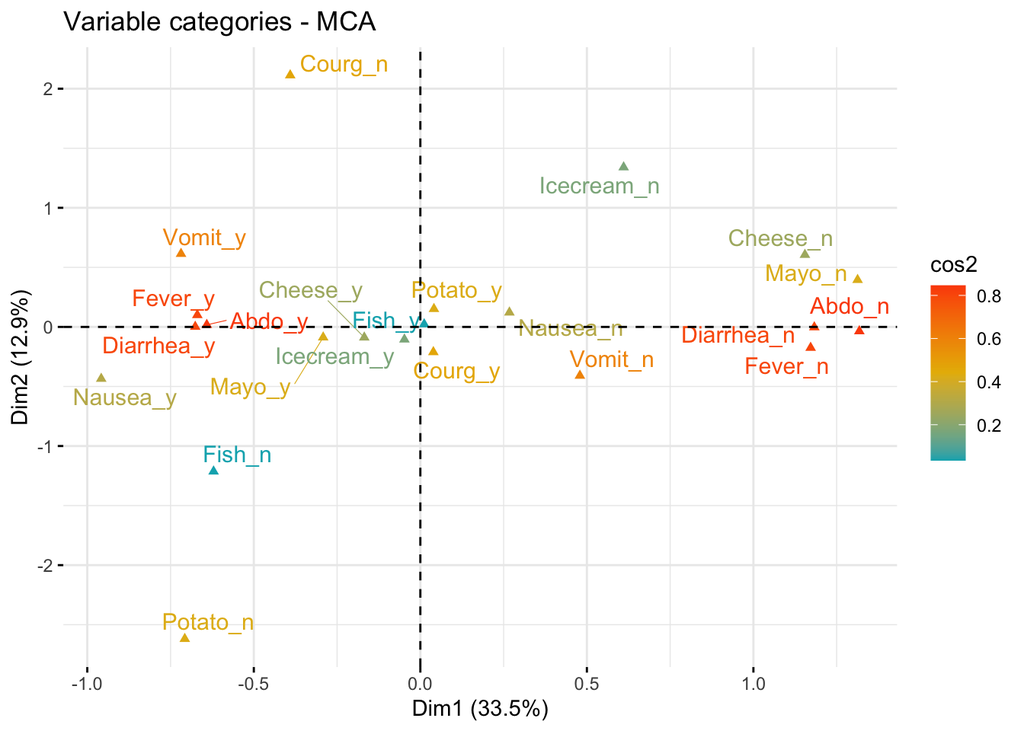

```r
# Colorer en fonction du cos2
fviz_mca_var(res.mca, col.var = "cos2",
             gradient.cols = c("#00AFBB", "#E7B800", "#FC4E07"),
             repel = TRUE,
             ggtheme = theme_minimal())
```

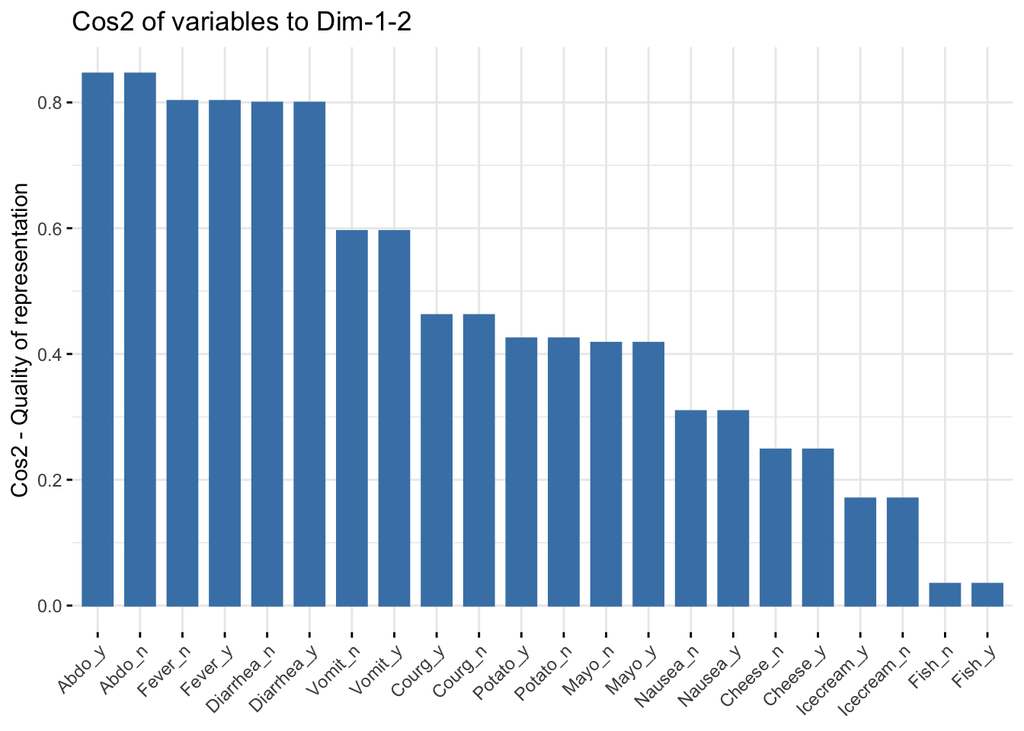

```r
# Cos2 des variable sur Dim.1 et Dim.2
fviz_cos2(res.mca, choice = "var", axes = 1:2)
```

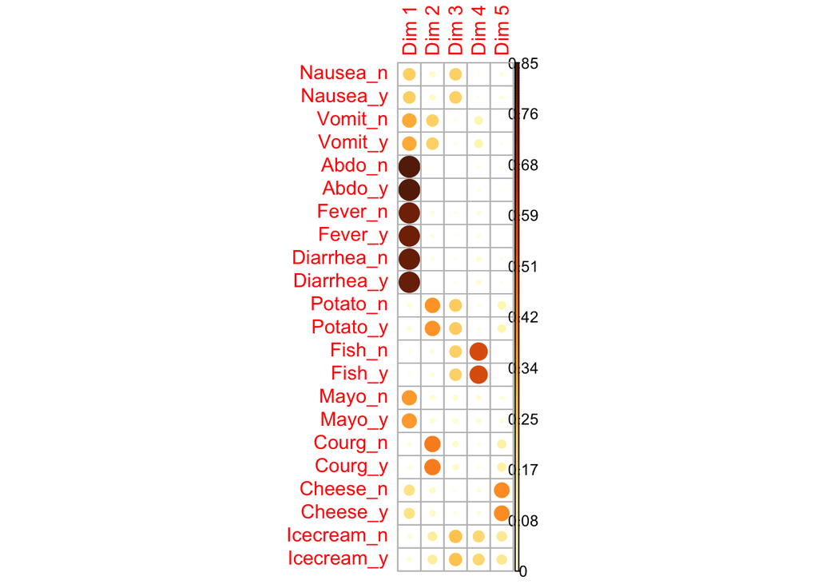

```r
library("corrplot")
corrplot(var$cos2, is.corr=FALSE)
```

### Contribution des variables aux dimensions

```r
head(round(var$contrib,2), 4)
```

```
         Dim 1 Dim 2 Dim 3 Dim 4 Dim 5
Nausea_n  1.52  0.81  4.67  0.08  0.49
Nausea_y  5.43  2.91 16.73  0.30  1.76
Vomit_n   3.73  7.07  0.36  4.26  0.19
Vomit_y   5.60 10.61  0.54  6.39  0.29
```

Les variables avec les plus grandes valeurs, contribuent le mieux à la définition des dimensions. Les catégories qui contribuent le plus à Dim.1 et Dim.2 sont les plus importantes pour expliquer la variabilité dans le jeu de données.

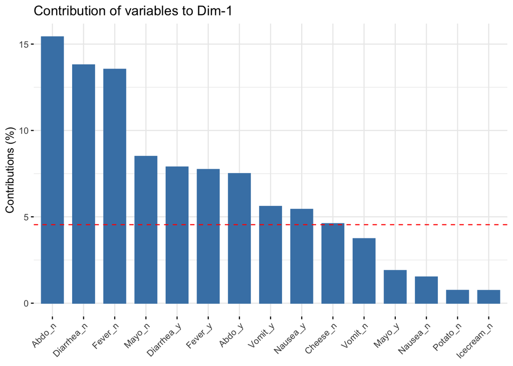

```r
# Contributions des variables à la dimension 1
fviz_contrib (res.mca, choice = "var", axes = 1, top = 15)
```

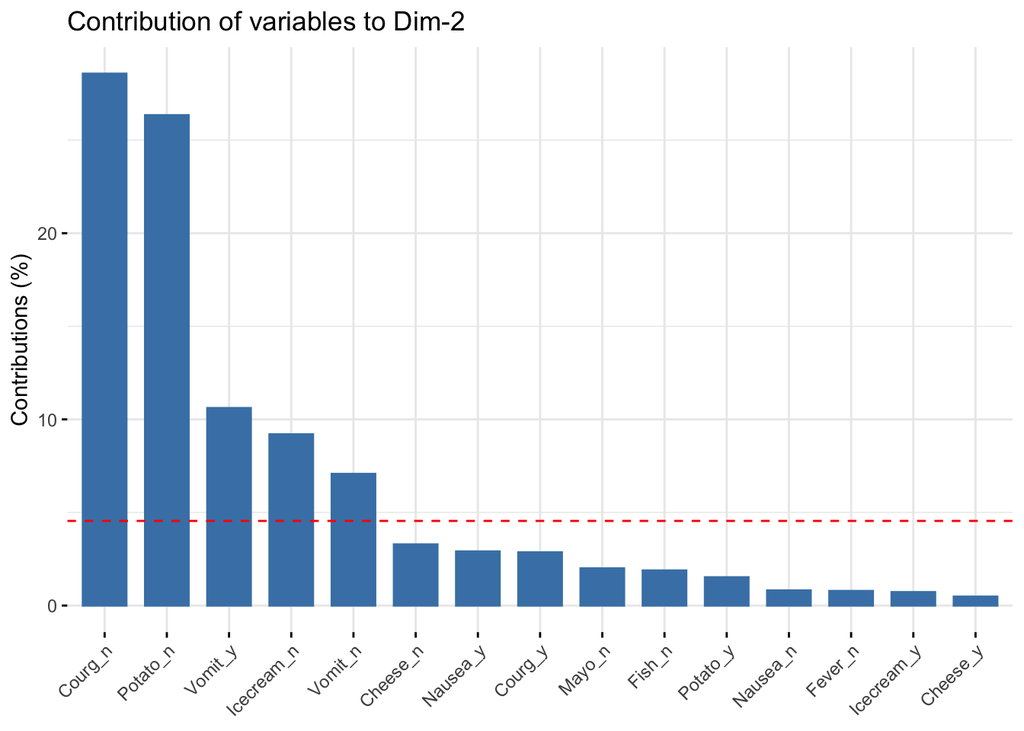

```r
# Contributions des variables à la dimension 2
fviz_contrib (res.mca, choice = "var", axes = 2, top = 15)
```

La ligne en pointillé rouge, sur le graphique ci-dessus, indique la valeur moyenne attendue sous l’hypothèse nulle.

Les variables Abdo_n, Diarrhea_n, Fever_n et Mayo_n sont les plus importantes dans la définition de la première dimension. Les catégories Courg_n, Potato_n, Vomit_y et Icecream_n contribuent le plus à la dimension 2.

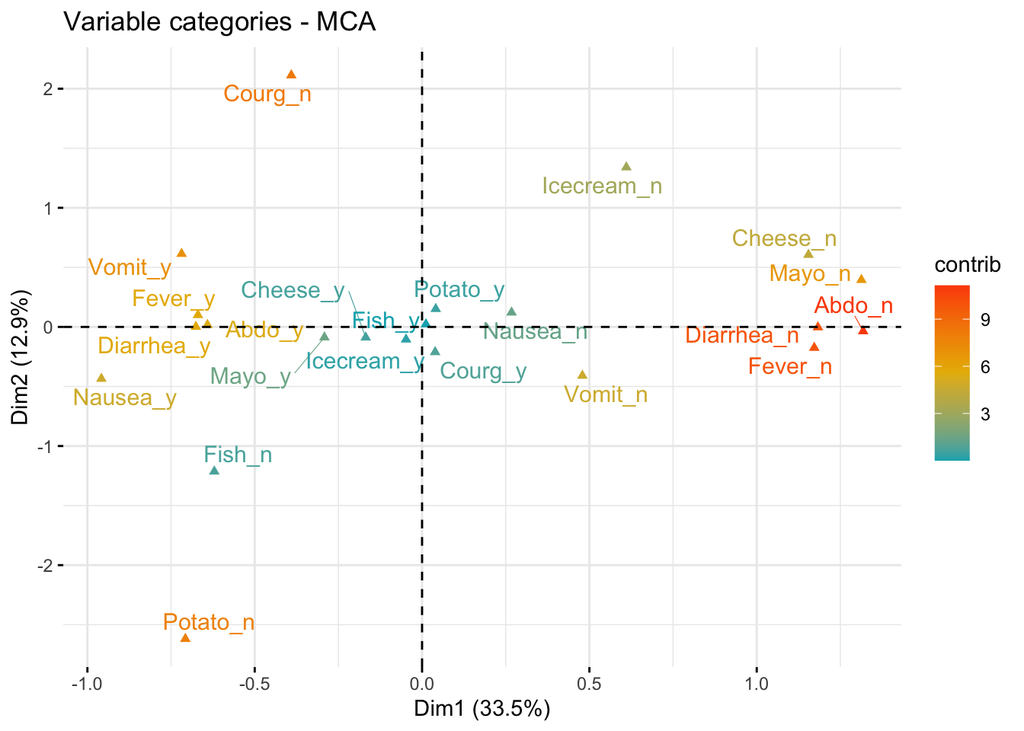

```r
fviz_mca_var(res.mca, col.var = "contrib",
             gradient.cols = c("#00AFBB", "#E7B800", "#FC4E07"),
             repel = TRUE,
             ggtheme = theme_minimal()
             )
```

### Les individus par groupes

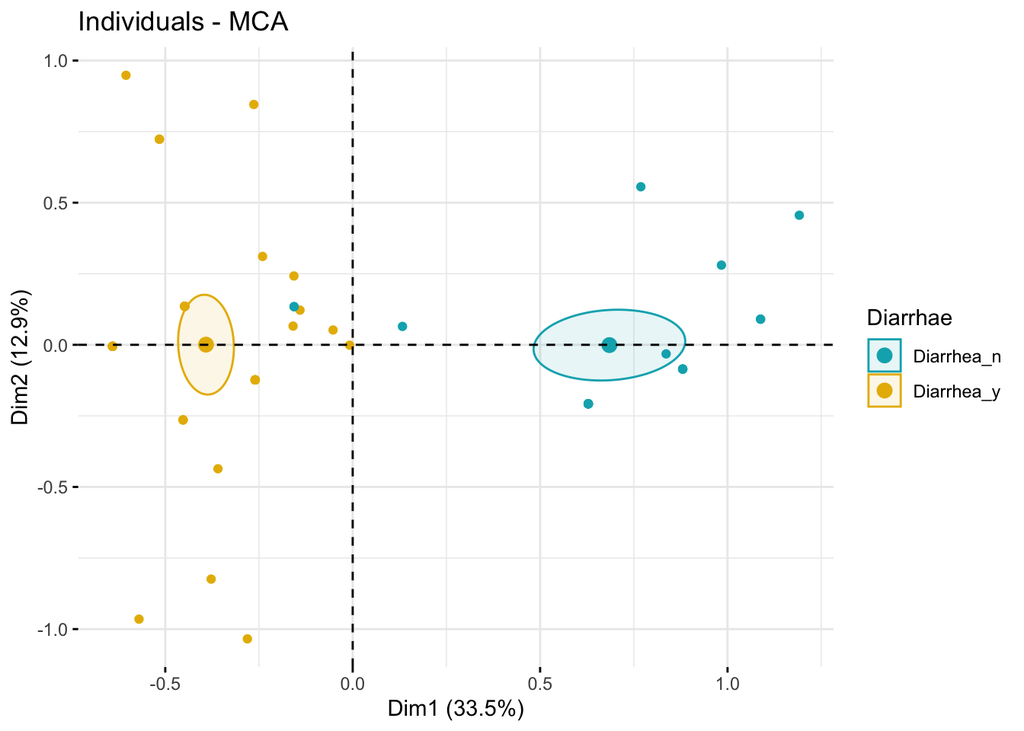

```r
fviz_mca_ind (res.mca,
             label = "none", # masquer le texte des individus
             habillage = "Diarrhae", # colorer par groupes
             palette = c ("#00AFBB", "#E7B800"),
             addEllipses = TRUE, ellipse.type = "confidence",
             ggtheme = theme_minimal ())
```

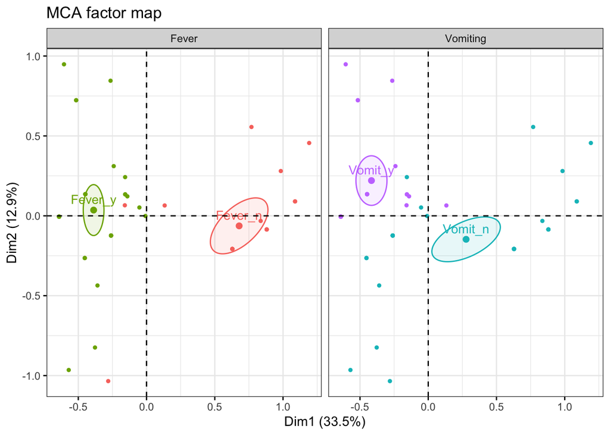

```r
fviz_ellipses(res.mca, c("Vomiting", "Fever"),
              geom = "point")
```